# Risk Factor Analysis

## Outcome Variable

**Outcome Variable:** wasted

## Predictor Variables

**Intervention Variable:** nrooms

**Adjustment Set:**

- arm
- sex
- W_mage
- meducyrs
- feducyrs
- hhwealth_quart
- hfoodsec
- W_mhtcm
- W_mwtkg
- W_mbmi
- W_nchldlt5
- W_parity
- impfloor
- impsan
- safeh20
- delta_W_mage
- delta_meducyrs
- delta_feducyrs
- delta_hhwealth_quart
- delta_hfoodsec
- delta_W_mhtcm
- delta_W_mwtkg
- delta_W_mbmi
- delta_W_nchldlt5
- delta_W_parity
- delta_impfloor
- delta_impsan
- delta_safeh20

## Stratifying Variables

The analysis was stratified on these variable(s):

- agecat
- studyid
- country

## Data Summary

| agecat | studyid | country | nrooms | wasted | n_cell | n |
| --- | --- | --- | --- | --- | --- | --- |
| Birth | CMC-V-BCS-2002 | INDIA | 4+ | 0 | 5 | 86 |
| Birth | CMC-V-BCS-2002 | INDIA | 4+ | 1 | 0 | 86 |
| Birth | CMC-V-BCS-2002 | INDIA | 1 | 0 | 31 | 86 |
| Birth | CMC-V-BCS-2002 | INDIA | 1 | 1 | 4 | 86 |
| Birth | CMC-V-BCS-2002 | INDIA | 2 | 0 | 21 | 86 |
| Birth | CMC-V-BCS-2002 | INDIA | 2 | 1 | 6 | 86 |
| Birth | CMC-V-BCS-2002 | INDIA | 3 | 0 | 18 | 86 |
| Birth | CMC-V-BCS-2002 | INDIA | 3 | 1 | 1 | 86 |
| Birth | COHORTS | INDIA | 4+ | 0 | 84 | 4454 |
| Birth | COHORTS | INDIA | 4+ | 1 | 6 | 4454 |
| Birth | COHORTS | INDIA | 1 | 0 | 2333 | 4454 |
| Birth | COHORTS | INDIA | 1 | 1 | 546 | 4454 |
| Birth | COHORTS | INDIA | 2 | 0 | 1121 | 4454 |
| Birth | COHORTS | INDIA | 2 | 1 | 207 | 4454 |
| Birth | COHORTS | INDIA | 3 | 0 | 141 | 4454 |
| Birth | COHORTS | INDIA | 3 | 1 | 16 | 4454 |
| Birth | CONTENT | PERU | 4+ | 0 | 1 | 2 |
| Birth | CONTENT | PERU | 4+ | 1 | 0 | 2 |
| Birth | CONTENT | PERU | 1 | 0 | 0 | 2 |
| Birth | CONTENT | PERU | 1 | 1 | 0 | 2 |
| Birth | CONTENT | PERU | 2 | 0 | 1 | 2 |
| Birth | CONTENT | PERU | 2 | 1 | 0 | 2 |
| Birth | CONTENT | PERU | 3 | 0 | 0 | 2 |
| Birth | CONTENT | PERU | 3 | 1 | 0 | 2 |
| Birth | GMS-Nepal | NEPAL | 4+ | 0 | 228 | 641 |
| Birth | GMS-Nepal | NEPAL | 4+ | 1 | 69 | 641 |
| Birth | GMS-Nepal | NEPAL | 1 | 0 | 33 | 641 |
| Birth | GMS-Nepal | NEPAL | 1 | 1 | 9 | 641 |
| Birth | GMS-Nepal | NEPAL | 2 | 0 | 112 | 641 |
| Birth | GMS-Nepal | NEPAL | 2 | 1 | 23 | 641 |

[output cut: 354 more lines]

The following strata were considered:

- agecat: 24 months, studyid: CMC-V-BCS-2002, country: INDIA
- agecat: 24 months, studyid: COHORTS, country: INDIA
- agecat: 24 months, studyid: CONTENT, country: PERU
- agecat: 24 months, studyid: GMS-Nepal, country: NEPAL
- agecat: 24 months, studyid: IRC, country: INDIA
- agecat: 24 months, studyid: JiVitA-3, country: BANGLADESH
- agecat: 24 months, studyid: JiVitA-4, country: BANGLADESH
- agecat: 24 months, studyid: MAL-ED, country: BANGLADESH
- agecat: 24 months, studyid: MAL-ED, country: BRAZIL
- agecat: 24 months, studyid: MAL-ED, country: INDIA
- agecat: 24 months, studyid: MAL-ED, country: NEPAL
- agecat: 24 months, studyid: MAL-ED, country: PERU
- agecat: 24 months, studyid: MAL-ED, country: SOUTH AFRICA
- agecat: 24 months, studyid: MAL-ED, country: TANZANIA, UNITED REPUBLIC OF
- agecat: 24 months, studyid: NIH-Crypto, country: BANGLADESH
- agecat: 24 months, studyid: PROVIDE, country: BANGLADESH
- agecat: 6 months, studyid: CMC-V-BCS-2002, country: INDIA
- agecat: 6 months, studyid: COHORTS, country: INDIA
- agecat: 6 months, studyid: CONTENT, country: PERU
- agecat: 6 months, studyid: GMS-Nepal, country: NEPAL
- agecat: 6 months, studyid: IRC, country: INDIA
- agecat: 6 months, studyid: JiVitA-3, country: BANGLADESH
- agecat: 6 months, studyid: JiVitA-4, country: BANGLADESH
- agecat: 6 months, studyid: MAL-ED, country: BANGLADESH
- agecat: 6 months, studyid: MAL-ED, country: BRAZIL
- agecat: 6 months, studyid: MAL-ED, country: INDIA
- agecat: 6 months, studyid: MAL-ED, country: NEPAL
- agecat: 6 months, studyid: MAL-ED, country: PERU
- agecat: 6 months, studyid: MAL-ED, country: SOUTH AFRICA
- agecat: 6 months, studyid: MAL-ED, country: TANZANIA, UNITED REPUBLIC OF
- agecat: 6 months, studyid: NIH-Crypto, country: BANGLADESH
- agecat: 6 months, studyid: PROVIDE, country: BANGLADESH
- agecat: Birth, studyid: CMC-V-BCS-2002, country: INDIA
- agecat: Birth, studyid: COHORTS, country: INDIA
- agecat: Birth, studyid: CONTENT, country: PERU
- agecat: Birth, studyid: GMS-Nepal, country: NEPAL
- agecat: Birth, studyid: IRC, country: INDIA
- agecat: Birth, studyid: JiVitA-3, country: BANGLADESH
- agecat: Birth, studyid: JiVitA-4, country: BANGLADESH
- agecat: Birth, studyid: MAL-ED, country: BANGLADESH
- agecat: Birth, studyid: MAL-ED, country: BRAZIL
- agecat: Birth, studyid: MAL-ED, country: INDIA
- agecat: Birth, studyid: MAL-ED, country: NEPAL
- agecat: Birth, studyid: MAL-ED, country: PERU
- agecat: Birth, studyid: MAL-ED, country: SOUTH AFRICA
- agecat: Birth, studyid: MAL-ED, country: TANZANIA, UNITED REPUBLIC OF
- agecat: Birth, studyid: NIH-Crypto, country: BANGLADESH
- agecat: Birth, studyid: PROVIDE, country: BANGLADESH

### Dropped Strata

Some strata were dropped due to rare outcomes:

- agecat: Birth, studyid: CMC-V-BCS-2002, country: INDIA
- agecat: Birth, studyid: CONTENT, country: PERU
- agecat: Birth, studyid: MAL-ED, country: BANGLADESH
- agecat: Birth, studyid: MAL-ED, country: BRAZIL
- agecat: Birth, studyid: MAL-ED, country: INDIA
- agecat: Birth, studyid: MAL-ED, country: NEPAL
- agecat: Birth, studyid: MAL-ED, country: PERU
- agecat: Birth, studyid: MAL-ED, country: SOUTH AFRICA
- agecat: Birth, studyid: MAL-ED, country: TANZANIA, UNITED REPUBLIC OF
- agecat: Birth, studyid: PROVIDE, country: BANGLADESH
- agecat: 6 months, studyid: CMC-V-BCS-2002, country: INDIA
- agecat: 6 months, studyid: COHORTS, country: INDIA
- agecat: 6 months, studyid: CONTENT, country: PERU
- agecat: 6 months, studyid: GMS-Nepal, country: NEPAL
- agecat: 6 months, studyid: IRC, country: INDIA
- agecat: 6 months, studyid: MAL-ED, country: BANGLADESH
- agecat: 6 months, studyid: MAL-ED, country: BRAZIL
- agecat: 6 months, studyid: MAL-ED, country: INDIA
- agecat: 6 months, studyid: MAL-ED, country: NEPAL
- agecat: 6 months, studyid: MAL-ED, country: PERU
- agecat: 6 months, studyid: MAL-ED, country: SOUTH AFRICA
- agecat: 6 months, studyid: MAL-ED, country: TANZANIA, UNITED REPUBLIC OF
- agecat: 6 months, studyid: NIH-Crypto, country: BANGLADESH
- agecat: 6 months, studyid: PROVIDE, country: BANGLADESH
- agecat: 24 months, studyid: CMC-V-BCS-2002, country: INDIA
- agecat: 24 months, studyid: COHORTS, country: INDIA
- agecat: 24 months, studyid: CONTENT, country: PERU
- agecat: 24 months, studyid: GMS-Nepal, country: NEPAL
- agecat: 24 months, studyid: IRC, country: INDIA
- agecat: 24 months, studyid: MAL-ED, country: BANGLADESH
- agecat: 24 months, studyid: MAL-ED, country: BRAZIL
- agecat: 24 months, studyid: MAL-ED, country: INDIA
- agecat: 24 months, studyid: MAL-ED, country: NEPAL
- agecat: 24 months, studyid: MAL-ED, country: PERU
- agecat: 24 months, studyid: MAL-ED, country: SOUTH AFRICA
- agecat: 24 months, studyid: MAL-ED, country: TANZANIA, UNITED REPUBLIC OF
- agecat: 24 months, studyid: NIH-Crypto, country: BANGLADESH
- agecat: 24 months, studyid: PROVIDE, country: BANGLADESH

## Methods Detail

We’re interested in the causal parameters $E[Y_a]$ for all values of $a \in \mathcal{A}$. These parameters represent the mean outcome if, possibly contrary to fact, we intervened to set all units to have $A=a$. Under the randomization and positivity assumptions, these are identified by the statistical parameters $\psi_a=E_W[E_{Y|A,W}(Y|A=a,W)]$. In addition, we’re interested in the mean of $Y$, $E[Y]$ under no intervention (the observed mean). We will estimate these parameters by using SuperLearner to fit the relevant likelihood factors – $E_{Y|A,W}(Y|A=a,W)$ and $p(A=a|W)$, and then updating our likelihood fit using a joint TMLE.

For unadjusted analyses ($W=\{\}$), initial likelihoods were estimated using Lrnr_glm to estimate the simple $E(Y|A)$ and Lrnr_mean to estimate $p(A)$. For adjusted analyses, a small library containing Lrnr_glmnet, Lrnr_xgboost, and Lrnr_mean was used.

Having estimated these parameters, we will then use the delta method to estimate relative risks and attributable risks relative to a prespecified baseline level of $A$.

# Results Detail

## Results Plots

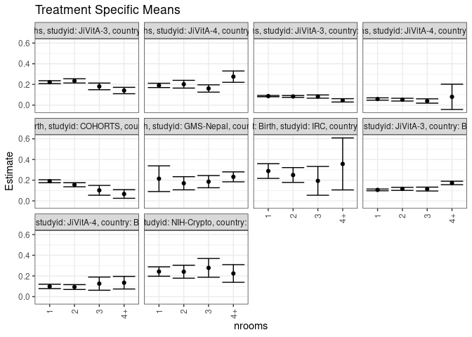

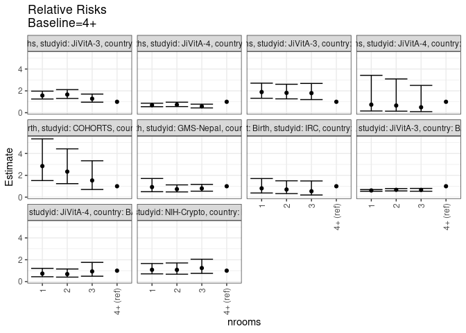

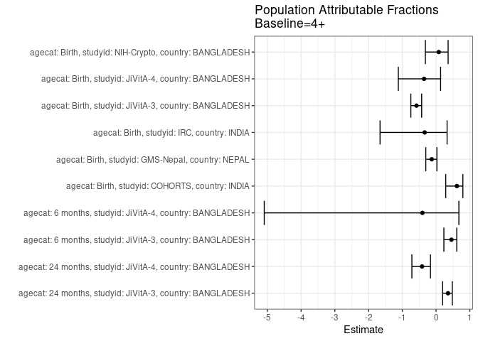

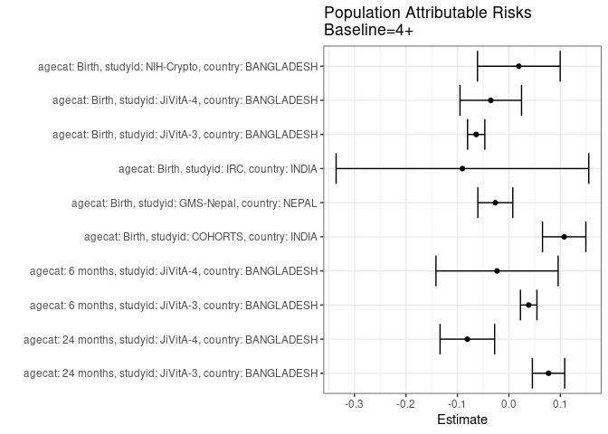

## Results Table

### Parameter: TSM

| agecat | studyid | country | intervention_level | baseline_level | estimate | ci_lower | ci_upper |
| --- | --- | --- | --- | --- | --- | --- | --- |
| Birth | COHORTS | INDIA | 4+ | NA | 0.0666667 | 0.0250085 | 0.1083249 |
| Birth | COHORTS | INDIA | 1 | NA | 0.1896492 | 0.1753277 | 0.2039707 |
| Birth | COHORTS | INDIA | 2 | NA | 0.1558735 | 0.1363621 | 0.1753849 |
| Birth | COHORTS | INDIA | 3 | NA | 0.1019108 | 0.0545830 | 0.1492387 |
| Birth | GMS-Nepal | NEPAL | 4+ | NA | 0.2323232 | 0.1842565 | 0.2803899 |
| Birth | GMS-Nepal | NEPAL | 1 | NA | 0.2142857 | 0.0900943 | 0.3384771 |
| Birth | GMS-Nepal | NEPAL | 2 | NA | 0.1703704 | 0.1069017 | 0.2338390 |
| Birth | GMS-Nepal | NEPAL | 3 | NA | 0.1856287 | 0.1266137 | 0.2446438 |
| Birth | IRC | INDIA | 4+ | NA | 0.3571429 | 0.1057806 | 0.6085051 |
| Birth | IRC | INDIA | 1 | NA | 0.2884615 | 0.2172637 | 0.3596594 |
| Birth | IRC | INDIA | 2 | NA | 0.2500000 | 0.1781673 | 0.3218327 |
| Birth | IRC | INDIA | 3 | NA | 0.1935484 | 0.0542683 | 0.3328284 |
| Birth | JiVitA-3 | BANGLADESH | 4+ | NA | 0.1731572 | 0.1566313 | 0.1896830 |
| Birth | JiVitA-3 | BANGLADESH | 1 | NA | 0.1060622 | 0.0976372 | 0.1144872 |
| Birth | JiVitA-3 | BANGLADESH | 2 | NA | 0.1159895 | 0.1013011 | 0.1306780 |
| Birth | JiVitA-3 | BANGLADESH | 3 | NA | 0.1141639 | 0.0955059 | 0.1328218 |
| Birth | JiVitA-4 | BANGLADESH | 4+ | NA | 0.1346407 | 0.0736754 | 0.1956059 |
| Birth | JiVitA-4 | BANGLADESH | 1 | NA | 0.0987629 | 0.0775186 | 0.1200073 |
| Birth | JiVitA-4 | BANGLADESH | 2 | NA | 0.0926485 | 0.0692331 | 0.1160639 |
| Birth | JiVitA-4 | BANGLADESH | 3 | NA | 0.1255027 | 0.0616166 | 0.1893888 |
| Birth | NIH-Crypto | BANGLADESH | 4+ | NA | 0.2239708 | 0.1384918 | 0.3094498 |
| Birth | NIH-Crypto | BANGLADESH | 1 | NA | 0.2424969 | 0.1970009 | 0.2879929 |
| Birth | NIH-Crypto | BANGLADESH | 2 | NA | 0.2407594 | 0.1781526 | 0.3033663 |
| Birth | NIH-Crypto | BANGLADESH | 3 | NA | 0.2779885 | 0.1872431 | 0.3687340 |
| 6 months | JiVitA-3 | BANGLADESH | 4+ | NA | 0.0460433 | 0.0300427 | 0.0620439 |
| 6 months | JiVitA-3 | BANGLADESH | 1 | NA | 0.0871642 | 0.0809269 | 0.0934015 |
| 6 months | JiVitA-3 | BANGLADESH | 2 | NA | 0.0836465 | 0.0746528 | 0.0926401 |
| 6 months | JiVitA-3 | BANGLADESH | 3 | NA | 0.0826504 | 0.0671191 | 0.0981817 |
| 6 months | JiVitA-4 | BANGLADESH | 4+ | NA | 0.0800354 | -0.0420507 | 0.2021215 |
| 6 months | JiVitA-4 | BANGLADESH | 1 | NA | 0.0589800 | 0.0477535 | 0.0702065 |
| 6 months | JiVitA-4 | BANGLADESH | 2 | NA | 0.0527308 | 0.0394649 | 0.0659967 |
| 6 months | JiVitA-4 | BANGLADESH | 3 | NA | 0.0397993 | 0.0188610 | 0.0607376 |
| 24 months | JiVitA-3 | BANGLADESH | 4+ | NA | 0.1409163 | 0.1100651 | 0.1717675 |
| 24 months | JiVitA-3 | BANGLADESH | 1 | NA | 0.2218687 | 0.2080685 | 0.2356689 |
| 24 months | JiVitA-3 | BANGLADESH | 2 | NA | 0.2342502 | 0.2137271 | 0.2547733 |
| 24 months | JiVitA-3 | BANGLADESH | 3 | NA | 0.1809090 | 0.1487310 | 0.2130870 |
| 24 months | JiVitA-4 | BANGLADESH | 4+ | NA | 0.2752360 | 0.2204047 | 0.3300672 |
| 24 months | JiVitA-4 | BANGLADESH | 1 | NA | 0.1906411 | 0.1698795 | 0.2114027 |
| 24 months | JiVitA-4 | BANGLADESH | 2 | NA | 0.2019969 | 0.1645931 | 0.2394008 |
| 24 months | JiVitA-4 | BANGLADESH | 3 | NA | 0.1608035 | 0.1255169 | 0.1960901 |

### Parameter: E(Y)

| agecat | studyid | country | intervention_level | baseline_level | estimate | ci_lower | ci_upper |
| --- | --- | --- | --- | --- | --- | --- | --- |
| Birth | COHORTS | INDIA | NA | NA | 0.1740009 | 0.1628660 | 0.1851358 |
| Birth | GMS-Nepal | NEPAL | NA | NA | 0.2059282 | 0.1745993 | 0.2372572 |
| Birth | IRC | INDIA | NA | NA | 0.2668622 | 0.2198462 | 0.3138781 |
| Birth | JiVitA-3 | BANGLADESH | NA | NA | 0.1096225 | 0.1044939 | 0.1147512 |
| Birth | JiVitA-4 | BANGLADESH | NA | NA | 0.0994152 | 0.0840401 | 0.1147903 |
| Birth | NIH-Crypto | BANGLADESH | NA | NA | 0.2432815 | 0.2116319 | 0.2749310 |
| 6 months | JiVitA-3 | BANGLADESH | NA | NA | 0.0844810 | 0.0796719 | 0.0892901 |
| 6 months | JiVitA-4 | BANGLADESH | NA | NA | 0.0569712 | 0.0481278 | 0.0658146 |
| 24 months | JiVitA-3 | BANGLADESH | NA | NA | 0.2179025 | 0.2080266 | 0.2277783 |
| 24 months | JiVitA-4 | BANGLADESH | NA | NA | 0.1945032 | 0.1812962 | 0.2077102 |

### Parameter: RR

| agecat | studyid | country | intervention_level | baseline_level | estimate | ci_lower | ci_upper |
| --- | --- | --- | --- | --- | --- | --- | --- |
| Birth | COHORTS | INDIA | 4+ | 4+ | 1.0000000 | 1.0000000 | 1.0000000 |
| Birth | COHORTS | INDIA | 1 | 4+ | 2.8447378 | 1.5159635 | 5.3382109 |
| Birth | COHORTS | INDIA | 2 | 4+ | 2.3381024 | 1.2362126 | 4.4221544 |
| Birth | COHORTS | INDIA | 3 | 4+ | 1.5286624 | 0.7017657 | 3.3298988 |
| Birth | GMS-Nepal | NEPAL | 4+ | 4+ | 1.0000000 | 1.0000000 | 1.0000000 |
| Birth | GMS-Nepal | NEPAL | 1 | 4+ | 0.9223602 | 0.4984751 | 1.7067020 |
| Birth | GMS-Nepal | NEPAL | 2 | 4+ | 0.7333333 | 0.4788895 | 1.1229683 |
| Birth | GMS-Nepal | NEPAL | 3 | 4+ | 0.7990107 | 0.5467877 | 1.1675794 |
| Birth | IRC | INDIA | 4+ | 4+ | 1.0000000 | 1.0000000 | 1.0000000 |
| Birth | IRC | INDIA | 1 | 4+ | 0.8076923 | 0.3831181 | 1.7027827 |
| Birth | IRC | INDIA | 2 | 4+ | 0.7000000 | 0.3272990 | 1.4971021 |
| Birth | IRC | INDIA | 3 | 4+ | 0.5419355 | 0.1980599 | 1.4828548 |
| Birth | JiVitA-3 | BANGLADESH | 4+ | 4+ | 1.0000000 | 1.0000000 | 1.0000000 |
| Birth | JiVitA-3 | BANGLADESH | 1 | 4+ | 0.6125197 | 0.5406775 | 0.6939078 |
| Birth | JiVitA-3 | BANGLADESH | 2 | 4+ | 0.6698512 | 0.5699947 | 0.7872014 |
| Birth | JiVitA-3 | BANGLADESH | 3 | 4+ | 0.6593076 | 0.5439033 | 0.7991981 |
| Birth | JiVitA-4 | BANGLADESH | 4+ | 4+ | 1.0000000 | 1.0000000 | 1.0000000 |
| Birth | JiVitA-4 | BANGLADESH | 1 | 4+ | 0.7335298 | 0.4451718 | 1.2086703 |
| Birth | JiVitA-4 | BANGLADESH | 2 | 4+ | 0.6881166 | 0.4103880 | 1.1537968 |
| Birth | JiVitA-4 | BANGLADESH | 3 | 4+ | 0.9321308 | 0.4936326 | 1.7601506 |
| Birth | NIH-Crypto | BANGLADESH | 4+ | 4+ | 1.0000000 | 1.0000000 | 1.0000000 |
| Birth | NIH-Crypto | BANGLADESH | 1 | 4+ | 1.0827165 | 0.7073792 | 1.6572088 |
| Birth | NIH-Crypto | BANGLADESH | 2 | 4+ | 1.0749590 | 0.6774233 | 1.7057826 |
| Birth | NIH-Crypto | BANGLADESH | 3 | 4+ | 1.2411819 | 0.7513887 | 2.0502473 |
| 6 months | JiVitA-3 | BANGLADESH | 4+ | 4+ | 1.0000000 | 1.0000000 | 1.0000000 |
| 6 months | JiVitA-3 | BANGLADESH | 1 | 4+ | 1.8930931 | 1.3246080 | 2.7055563 |
| 6 months | JiVitA-3 | BANGLADESH | 2 | 4+ | 1.8166926 | 1.2672645 | 2.6043275 |
| 6 months | JiVitA-3 | BANGLADESH | 3 | 4+ | 1.7950588 | 1.2022662 | 2.6801353 |
| 6 months | JiVitA-4 | BANGLADESH | 4+ | 4+ | 1.0000000 | 1.0000000 | 1.0000000 |
| 6 months | JiVitA-4 | BANGLADESH | 1 | 4+ | 0.7369239 | 0.1586802 | 3.4223345 |
| 6 months | JiVitA-4 | BANGLADESH | 2 | 4+ | 0.6588432 | 0.1404040 | 3.0916096 |
| 6 months | JiVitA-4 | BANGLADESH | 3 | 4+ | 0.4972710 | 0.0988406 | 2.5017894 |
| 24 months | JiVitA-3 | BANGLADESH | 4+ | 4+ | 1.0000000 | 1.0000000 | 1.0000000 |
| 24 months | JiVitA-3 | BANGLADESH | 1 | 4+ | 1.5744710 | 1.2546711 | 1.9757839 |
| 24 months | JiVitA-3 | BANGLADESH | 2 | 4+ | 1.6623355 | 1.3058784 | 2.1160923 |
| 24 months | JiVitA-3 | BANGLADESH | 3 | 4+ | 1.2838045 | 0.9660344 | 1.7061028 |
| 24 months | JiVitA-4 | BANGLADESH | 4+ | 4+ | 1.0000000 | 1.0000000 | 1.0000000 |
| 24 months | JiVitA-4 | BANGLADESH | 1 | 4+ | 0.6926461 | 0.5511057 | 0.8705384 |
| 24 months | JiVitA-4 | BANGLADESH | 2 | 4+ | 0.7339046 | 0.5597564 | 0.9622327 |
| 24 months | JiVitA-4 | BANGLADESH | 3 | 4+ | 0.5842386 | 0.4368489 | 0.7813566 |

### Parameter: PAR

| agecat | studyid | country | intervention_level | baseline_level | estimate | ci_lower | ci_upper |
| --- | --- | --- | --- | --- | --- | --- | --- |
| Birth | COHORTS | INDIA | 4+ | NA | 0.1073342 | 0.0652317 | 0.1494368 |
| Birth | GMS-Nepal | NEPAL | 4+ | NA | -0.0263950 | -0.0603201 | 0.0075301 |
| Birth | IRC | INDIA | 4+ | NA | -0.0902807 | -0.3356486 | 0.1550872 |
| Birth | JiVitA-3 | BANGLADESH | 4+ | NA | -0.0635346 | -0.0802724 | -0.0467968 |
| Birth | JiVitA-4 | BANGLADESH | 4+ | NA | -0.0352255 | -0.0949953 | 0.0245444 |
| Birth | NIH-Crypto | BANGLADESH | 4+ | NA | 0.0193107 | -0.0609955 | 0.0996168 |
| 6 months | JiVitA-3 | BANGLADESH | 4+ | NA | 0.0384377 | 0.0224272 | 0.0544483 |
| 6 months | JiVitA-4 | BANGLADESH | 4+ | NA | -0.0230642 | -0.1417191 | 0.0955907 |
| 24 months | JiVitA-3 | BANGLADESH | 4+ | NA | 0.0769861 | 0.0455915 | 0.1083807 |
| 24 months | JiVitA-4 | BANGLADESH | 4+ | NA | -0.0807328 | -0.1337394 | -0.0277262 |

### Parameter: PAF

| agecat | studyid | country | intervention_level | baseline_level | estimate | ci_lower | ci_upper |
| --- | --- | --- | --- | --- | --- | --- | --- |
| Birth | COHORTS | INDIA | 4+ | NA | 0.6168602 | 0.2862315 | 0.7943365 |
| Birth | GMS-Nepal | NEPAL | 4+ | NA | -0.1281757 | -0.3049988 | 0.0246885 |
| Birth | IRC | INDIA | 4+ | NA | -0.3383046 | -1.6601876 | 0.3267170 |
| Birth | JiVitA-3 | BANGLADESH | 4+ | NA | -0.5795764 | -0.7481567 | -0.4272528 |
| Birth | JiVitA-4 | BANGLADESH | 4+ | NA | -0.3543267 | -1.1192865 | 0.1345197 |
| Birth | NIH-Crypto | BANGLADESH | 4+ | NA | 0.0793758 | -0.3174664 | 0.3566827 |
| 6 months | JiVitA-3 | BANGLADESH | 4+ | NA | 0.4549867 | 0.2314334 | 0.6135150 |
| 6 months | JiVitA-4 | BANGLADESH | 4+ | NA | -0.4048399 | -5.0928053 | 0.6760811 |
| 24 months | JiVitA-3 | BANGLADESH | 4+ | NA | 0.3533055 | 0.1950666 | 0.4804368 |
| 24 months | JiVitA-4 | BANGLADESH | 4+ | NA | -0.4150718 | -0.7168258 | -0.1663550 |